# ST3131

As the ID and Hgt_m are redundant in the dataset, we remove them.

```
##    Min. 1st Qu.  Median    Mean 3rd Qu.    Max.
##   0.790   1.982   2.550   2.637   3.118   5.790
```

For the variables, Age, Hgt are continuous variables, while Sex and Smoke are indicator variables.

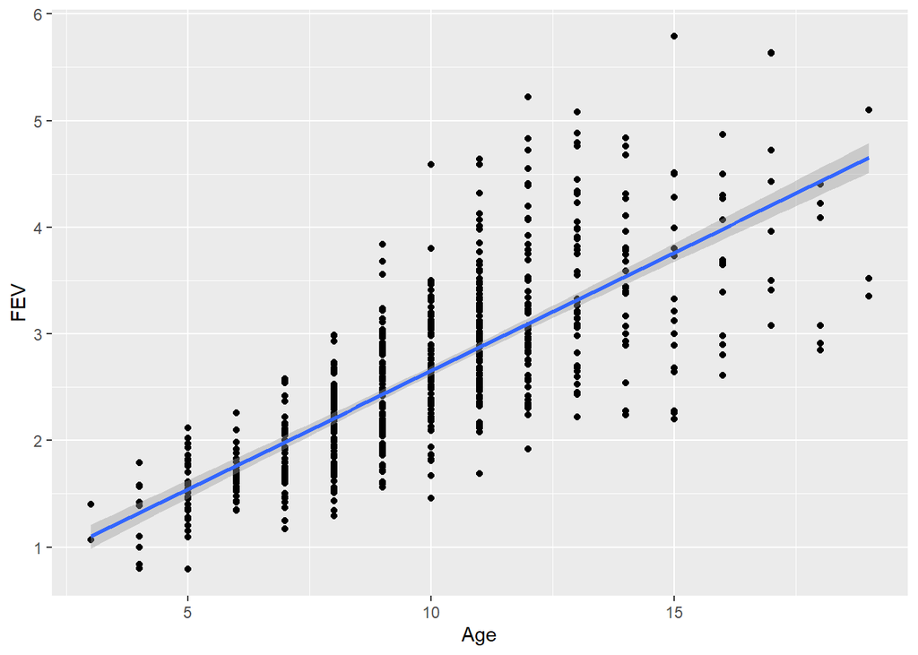

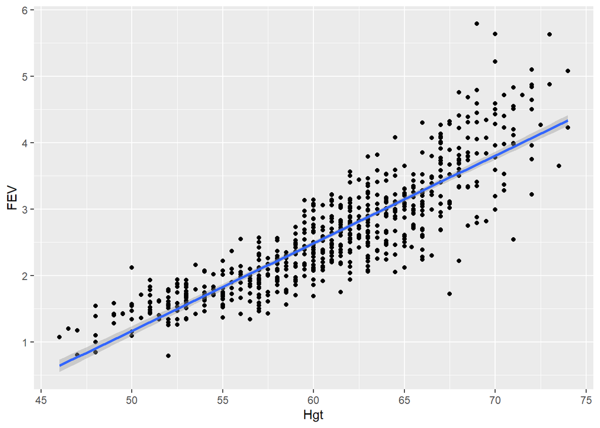

From the plots we can See that there is positive correlation between Age and FEV as well as between Hgt and FEV.

To examine the effect of smoking on FEV, we divide the dataset into smokers and non-smokers.

As the youngest smoker is 9 years old, we need to subset the non-smoker dataset by Age>=9 years old.

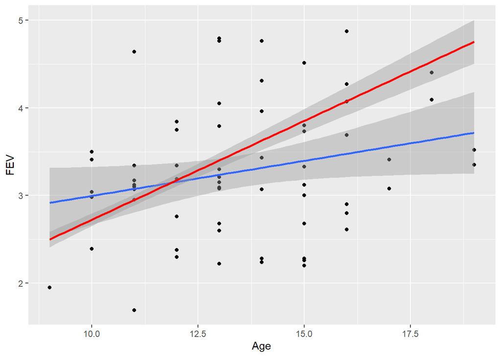

From the plot we can see that the best-fit line of non-smoker is steeper, which means that the coefficient is larger. This means that as Age increases, FEV of non-smokers increases more than that of smokers, which shows that there is a negative correlation between smoking and FEV.

To examine the effect of different gender on FEV, we divide the dataset into male and female.

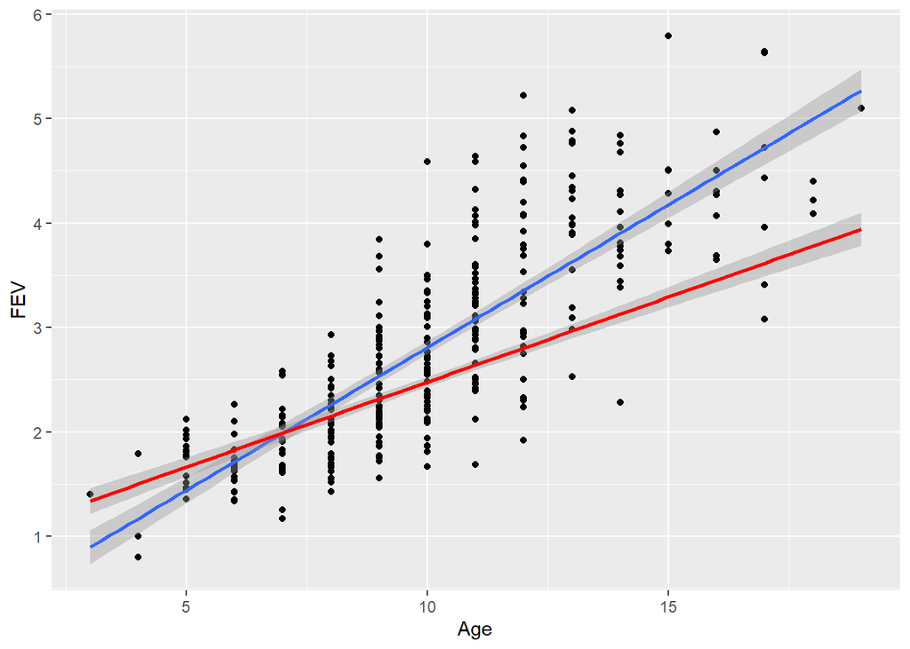

From the plot we can see that the best fit line of male is steeper,which means that the coefficient is lager. This means that as Age increases, FEV of male increases more than that of female.

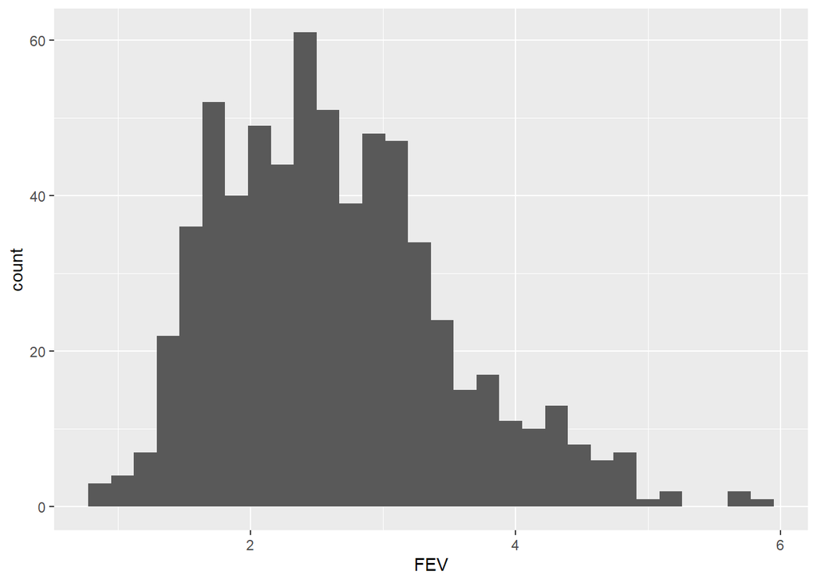

The response could be a normal distribution.

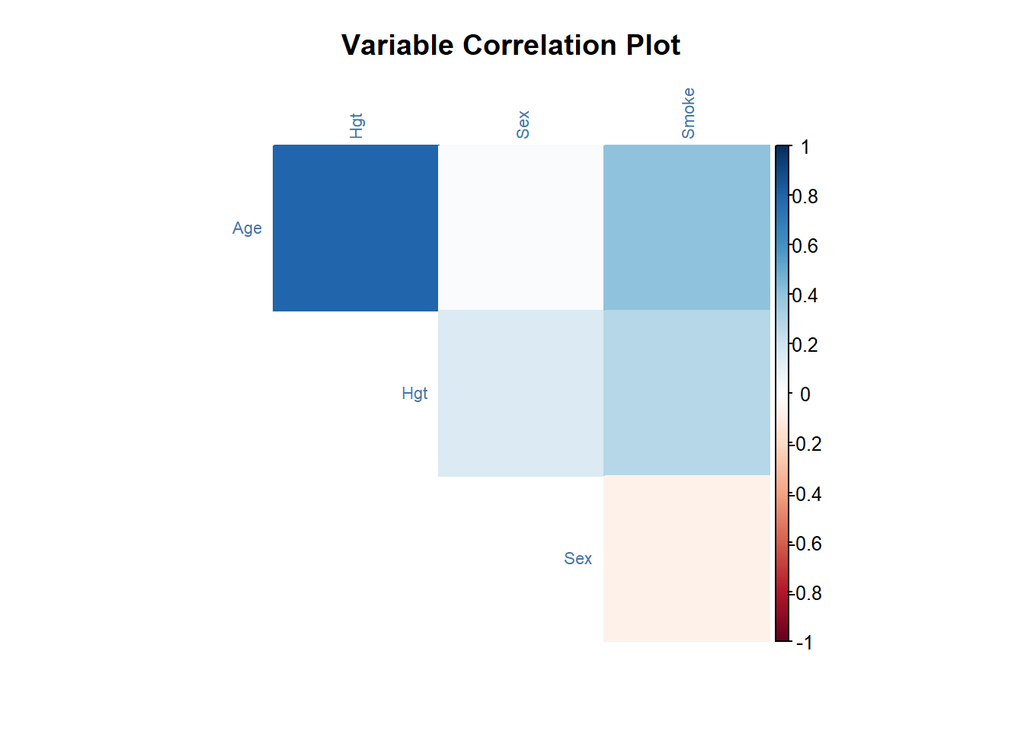

Age and Hgt, Age and Smoke has relatively strong relationship

```
##
## Call:
## lm(formula = FEV ~ Hgt + Age + Sex + Smoke, data = data)
##
## Residuals:
##      Min       1Q   Median       3Q      Max
## -1.38104 -0.24963  0.00817  0.25462  1.91721
##
## Coefficients:
##              Estimate Std. Error t value Pr(>|t|)
## (Intercept) -4.455340   0.222770 -20.000  < 2e-16 ***
## Hgt          0.104182   0.004756  21.904  < 2e-16 ***
## Age          0.065510   0.009486   6.906 1.19e-11 ***
## Sex          0.156909   0.033197   4.727 2.80e-06 ***
## Smoke       -0.086846   0.059235  -1.466    0.143
## ---
## Signif. codes:  0 '***' 0.001 '**' 0.01 '*' 0.05 '.' 0.1 ' ' 1
##
## Residual standard error: 0.4121 on 649 degrees of freedom
## Multiple R-squared:  0.7754, Adjusted R-squared:  0.774
## F-statistic: 560.2 on 4 and 649 DF,  p-value: < 2.2e-16
```

```
## Analysis of Variance Table
##
## Response: FEV
##            Df Sum Sq Mean Sq   F value    Pr(>F)
## Hgt         1 369.91  369.91 2178.2904 < 2.2e-16 ***
## Age         1   6.27    6.27   36.8971 2.121e-09 ***
## Sex         1   4.02    4.02   23.6510 1.451e-06 ***
## Smoke       1   0.37    0.37    2.1495    0.1431
## Residuals 649 110.21    0.17
## ---
## Signif. codes:  0 '***' 0.001 '**' 0.01 '*' 0.05 '.' 0.1 ' ' 1
```

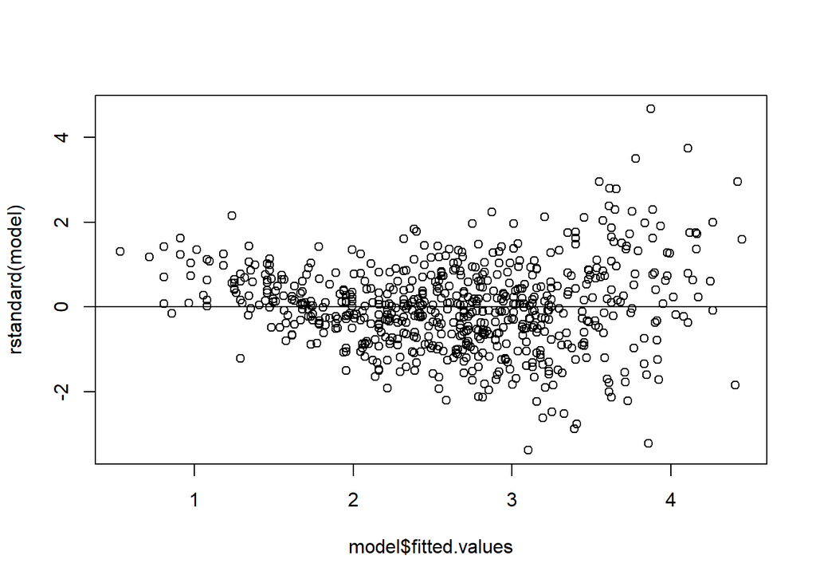

From the summary table, we can see that Hgt, Age, Sex are significant variables as the p-value is very small. Smoke is not a significant variable. This may not be the case as shown by the earlier plot and by common sense, smoking would affect FEV. We can see that the residual is not randomly distributed around 0 which contradicts the assumption of a linear model. Therefore we need a better model.

```
##
## Call:
## lm(formula = log(FEV) ~ Hgt + Age + Sex + Smoke, data = data)
##
## Residuals:
##      Min       1Q   Median       3Q      Max
## -0.63443 -0.08644  0.01167  0.09492  0.40904
##
## Coefficients:
##              Estimate Std. Error t value Pr(>|t|)
## (Intercept) -1.942930   0.078618 -24.713  < 2e-16 ***
## Hgt          0.042783   0.001679  25.488  < 2e-16 ***
## Age          0.023387   0.003348   6.986 7.01e-12 ***
## Sex          0.029236   0.011716   2.496   0.0128 *
## Smoke       -0.046015   0.020905  -2.201   0.0281 *
## ---
## Signif. codes:  0 '***' 0.001 '**' 0.01 '*' 0.05 '.' 0.1 ' ' 1
##
## Residual standard error: 0.1454 on 649 degrees of freedom
## Multiple R-squared:  0.8106, Adjusted R-squared:  0.8095
## F-statistic: 694.6 on 4 and 649 DF,  p-value: < 2.2e-16
```

```
## Analysis of Variance Table
##
## Response: log(FEV)
##            Df Sum Sq Mean Sq   F value    Pr(>F)
## Hgt         1 57.672  57.672 2726.8006 < 2.2e-16 ***
## Age         1  0.835   0.835   39.4653 6.121e-10 ***
## Sex         1  0.152   0.152    7.2095  0.007437 **
## Smoke       1  0.102   0.102    4.8452  0.028075 *
## Residuals 649 13.726   0.021
## ---
## Signif. codes:  0 '***' 0.001 '**' 0.01 '*' 0.05 '.' 0.1 ' ' 1
```

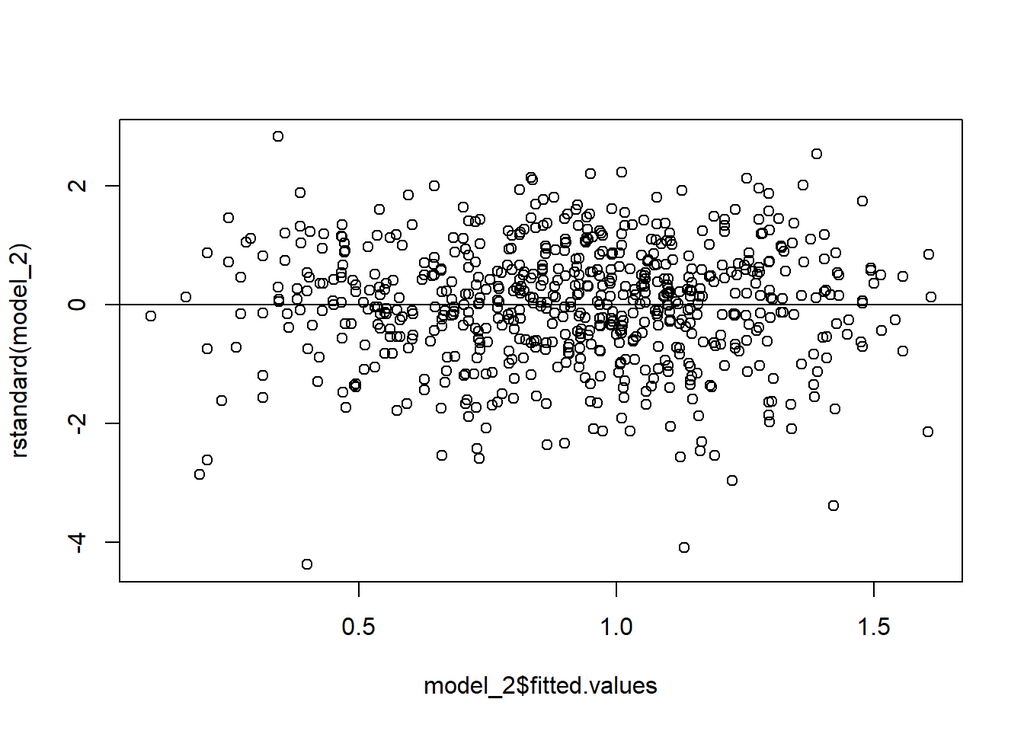

```
## Start:  AIC=-185.79
## FEV ~ 1
##
##         Df Sum of Sq    RSS      AIC
## + Hgt    1    369.91 120.86 -1100.28
## + Age    1    280.89 209.87  -739.34
## + Smoke  1     29.60 461.17  -224.47
## + Sex    1     21.30 469.47  -212.80
## <none>               490.77  -185.79
##
## Step:  AIC=-1100.28
## FEV ~ Hgt
##
##         Df Sum of Sq    RSS     AIC
## + Age    1    6.2657 114.59 -1133.1
## + Sex    1    2.4842 118.37 -1111.9
## <none>               120.86 -1100.3
## + Smoke  1    0.0025 120.86 -1098.3
##
## Step:  AIC=-1133.09
## FEV ~ Hgt + Age
##
##         Df Sum of Sq    RSS     AIC
## + Sex    1    4.0163 110.58 -1154.4
## + Smoke  1    0.5875 114.00 -1134.5
## <none>               114.59 -1133.1
##
## Step:  AIC=-1154.42
## FEV ~ Hgt + Age + Sex
##
##         Df Sum of Sq    RSS     AIC
## + Smoke  1   0.36502 110.21 -1154.6
## <none>               110.58 -1154.4
##
## Step:  AIC=-1154.59
## FEV ~ Hgt + Age + Sex + Smoke
```

```
##
## Call:
## lm(formula = FEV ~ Hgt + Age + Sex + Smoke, data = data)
##
## Residuals:
##      Min       1Q   Median       3Q      Max
## -1.38104 -0.24963  0.00817  0.25462  1.91721
##
## Coefficients:
##              Estimate Std. Error t value Pr(>|t|)
## (Intercept) -4.455340   0.222770 -20.000  < 2e-16 ***
## Hgt          0.104182   0.004756  21.904  < 2e-16 ***
## Age          0.065510   0.009486   6.906 1.19e-11 ***
## Sex          0.156909   0.033197   4.727 2.80e-06 ***
## Smoke       -0.086846   0.059235  -1.466    0.143
## ---
## Signif. codes:  0 '***' 0.001 '**' 0.01 '*' 0.05 '.' 0.1 ' ' 1
##
## Residual standard error: 0.4121 on 649 degrees of freedom
## Multiple R-squared:  0.7754, Adjusted R-squared:  0.774
## F-statistic: 560.2 on 4 and 649 DF,  p-value: < 2.2e-16
```

```
## Start:  AIC=-2516.91
## log(FEV) ~ Hgt + Age + Sex + Smoke
##
##         Df Sum of Sq    RSS     AIC
## <none>               13.726 -2516.9
## - Smoke  1    0.1025 13.829 -2514.1
## - Sex    1    0.1317 13.858 -2512.7
## - Age    1    1.0323 14.759 -2471.5
## - Hgt    1   13.7401 27.467 -2065.3
```

```
##
## Call:
## lm(formula = log(FEV) ~ Hgt + Age + Sex + Smoke, data = data)
##
## Residuals:
##      Min       1Q   Median       3Q      Max
## -0.63443 -0.08644  0.01167  0.09492  0.40904
##
## Coefficients:
##              Estimate Std. Error t value Pr(>|t|)
## (Intercept) -1.942930   0.078618 -24.713  < 2e-16 ***
## Hgt          0.042783   0.001679  25.488  < 2e-16 ***
## Age          0.023387   0.003348   6.986 7.01e-12 ***
## Sex          0.029236   0.011716   2.496   0.0128 *
## Smoke       -0.046015   0.020905  -2.201   0.0281 *
## ---
## Signif. codes:  0 '***' 0.001 '**' 0.01 '*' 0.05 '.' 0.1 ' ' 1
##
## Residual standard error: 0.1454 on 649 degrees of freedom
## Multiple R-squared:  0.8106, Adjusted R-squared:  0.8095
## F-statistic: 694.6 on 4 and 649 DF,  p-value: < 2.2e-16
```

From the result of variable selection, we can keep all 4 variables.

From the summary table of the second model which is the improved model. We can see that the p-value of every variable is significant while Hgt and Age are more significant compared to Sex and Smoke. The residual is randomly distributed around 0 therefore it is a good estimation of linear model.

Therefore the final model I selected would be model_2 which is a multiple linear regression model between ln(FEV) and Hgt, Age, Sex and Smoke. We can see that 1 inch increase in height would increase ln(FEV) by 0.042783, 1 year increase in age would increase ln(FEV) by 0.023387. Male has a higher ln(FEV) of 0.029236 compared to Female and non-smoker has a higher ln(FEV) of 0.046015 compared to smokers. The result reflects the relationships of different variables with FEV shown in Part I.